# Rule Based Template System

## Overview

The objective is to convert the raw text and expression from a business rule questionnaire to source code with the help of json rule templating system.

The reason behind this objective is to automate the data quality pipeline with generic and dynamic business rule, which means there will be only one generic pipeline for any given dataset in order to check the data quality.

Generic Data Quality package is already existing and is also applied on the petchem data quality POC. The next step is to configure the dynamic business rule; which is different for different kinds of dataset.

### Underlying Idea

The underlying idea to configure the dynamic business rule to an existing data quality pipeline juggles with few components. Please check the different section in order to get the more information on the component. Below are the components,

- Questionnaire Interface
- Extractor
- JSON Rule Template File
- Source Code JSON File

Every concerned stakeholder of SP Global Platts will have access to the questionnaire interface, where they can actually create business rule by selecting appropriate template which will precise information. To start with, we are using existing pattern of business rule which can be defined in base template.

- Base Template [Please go to template section to see how the template can be defined].

Extractor engine takes the input such as Pipeline name, business rule name, definition, expression, operator and logical operator. It extract the precise information required by the base class in order to activate the various operaton and functions of the corresponding rule template.

At last, source code creator file orchestrate and activates the actual function from the base class which will be used in data quality pipeline for business rule check.

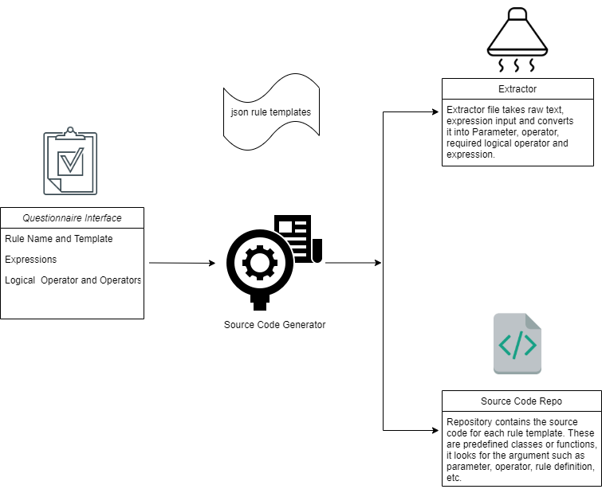

### Questionnaire Interface

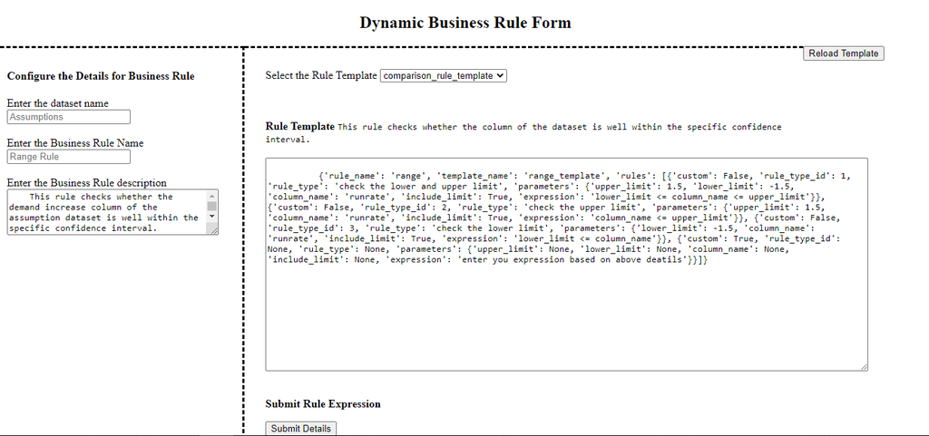

### Rule Templates

There are different kinds of template in order to articulate a business rule. As of now, due to lack of patterns on rules which emerges in different industry, only few templates are available. Team is coming up with more rule template and in short time it will be full of templates.

The rule template actually consist of placeholders. In order to define any business rule for a given dataset, it is important to mention the few details and the relationship to be tested on features of the dataset. The required information from each type of template is self explanatory.

For the demonstration of the product lifecycle, We are going to start with couple of rule templates,

#### Base Template

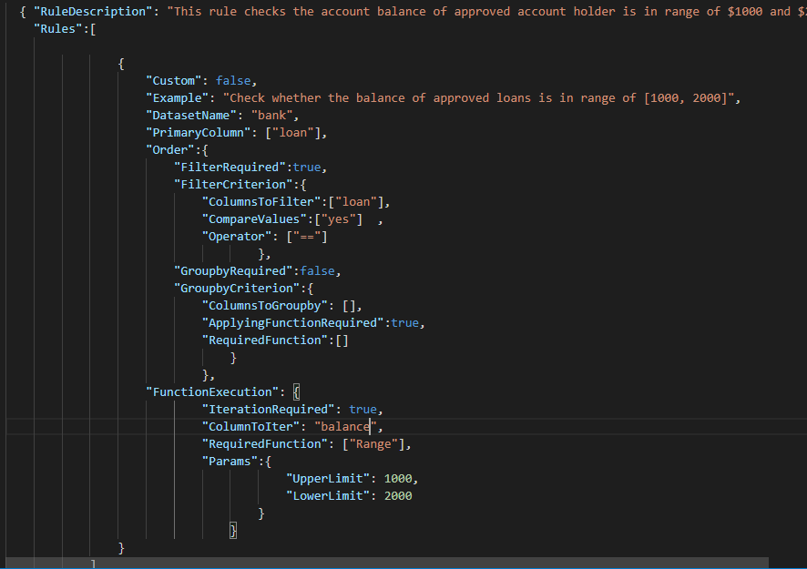

#### Content

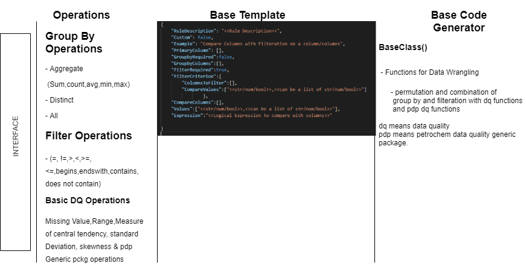

### Backend Files

Once the information is received on the front end, they are immediately stored in cache and uploaded to S3 bucket against certain ID. This information may be exposed with an api which can be supplied to the quality pipeline.

Below are the files and their respective functions,

#### Base Class

Base class contains the various data wrangling operations such as filter, group_by, order by, etc. and various statistical function confined to data quality such as missing value, range, outlier, measure of central tendencies.

Base Class gets the information from the rule template as an arguments. In other words Rule Template Rule Keys are variables which is initialised in base class and they contains the information which is required by different operation mentioned in base class.

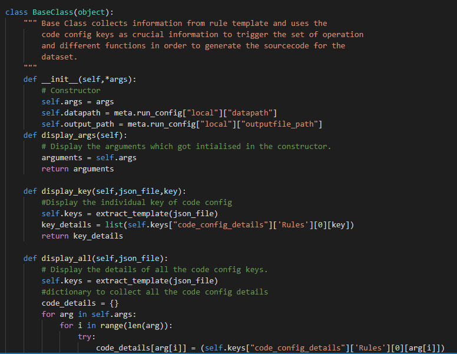

#### Source Code Creator File

This is a python file which acts as an orchestrator and it activate the operations written in base class and it applies the business rule on the actual dataset and export the dataframe in .csv format.

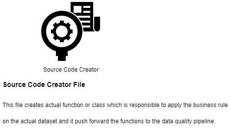